# Jornada 1: Introducción a R

## Paquetes de R: Instalándolos y usándolos

Los paquetes son una agrupación de funciones y/o conjuntos de datos que comparten un tema similar. Ej: estadísticas, análisis espacial, creacion de gráficos, etc. Cualquier usuario puede desarrollar paquetes y ponerlos a disposición de otros usuarios de R. Por lo general, están disponibles a través del [CRAN – Comprehensive R Archive Network](https://cran.r-project.org/web/packages/).

Actualmente, hay 17432 paquetes disponibles públicamente.

Para instalar paquetes en su computadora, use la función `install.packages ()`

```r
> install.packages ("ggplot2")
## Installing package into 'C:/Users/ASUS/OneDrive/Documentos/R/win-library/4.0'
## (as 'lib' is unspecified)
## Error in contrib.url(repos, "source"): trying to use CRAN without setting a mirror
```

```r
> qplot (1:10, 1:10)
## Error in qplot(1:10, 1:10): could not find function "qplot"
```

`Error: could not find function “qplot”` (Error: no se pudo encontrar la función “qplot”)

Para poder usar la función `qplot()` necesitamos cargar el paquete ggplot2 antes.

```r
> library("ggplot2")
> qplot (1:10, 1:10)
```

Ahora se encuentra la función y la ejecución de nuestro código conduce al siguiente gráfico:

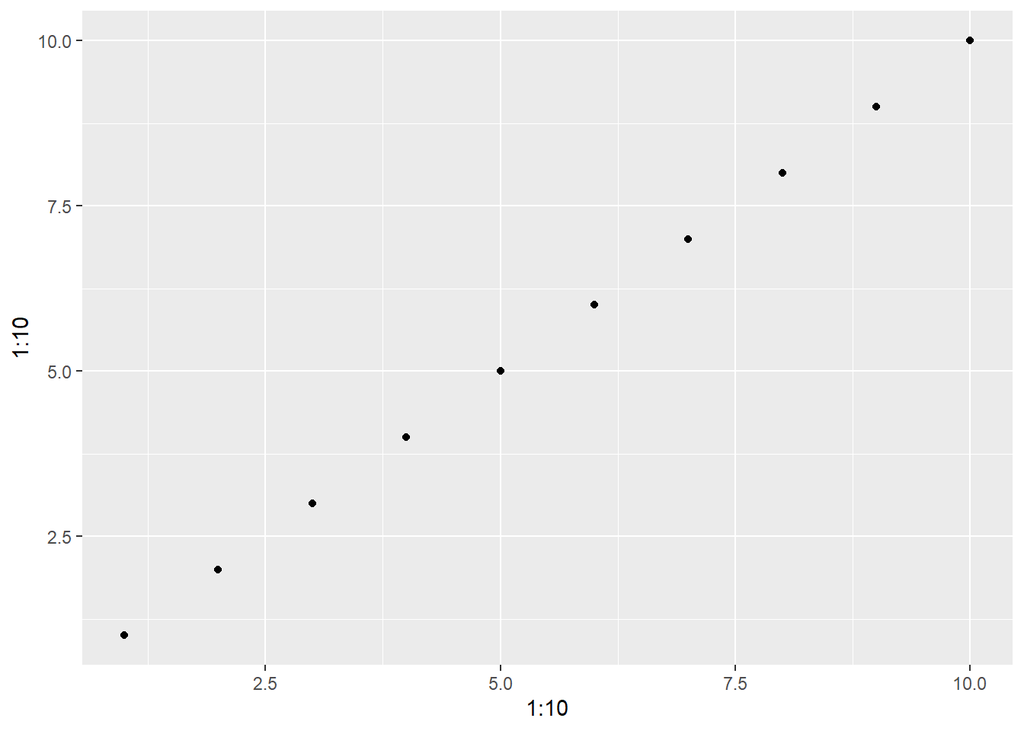

Es una buena práctica descargar los paquetes una vez que hayamos terminado con ellos porque podría entrar en conflicto con otros paquetes. La descarga de un paquete se realiza con la función `detach()` y especificando que es un paquete:

```r
> detach(package:ggplot2)
```

## Obteniendo ayuda

Hasta ahora hemos visto que R es realmente versátil y ofrece muchas funciones con las que podemos trabajar. Entre todas estas funciones, probablemente haya algunas que puedan hacer lo que queramos. Ahora el problema es: ¿cómo encontrar estas funciones?

Para encontrar una función que haga algo específico en los paquetes que hemos instalado, podemos usar el operador `??` (o la función `help.search()`). Para realizar una búsqueda, simplemente se escribe `??` y lo que deseamos buscar. Por ejemplo, digamos que queremos crear una secuencia de números impares entre 0 y 10. Buscaremos en nuestros paquetes todas las funciones que contengan la palabra **sequence** (secuencia).

**IMPORTANTE**

La gran mayoría de paquetes y funciones han sido creadas en inglés, por lo que debemos buscar la función que deseamos utilizando la palabra en inglés.

```r
??sequence
```

Esto nos muestra lo siguiente en la pestaña **ayuda** en el recuadro derecha-abajo en nuestro RStudio (Nota: el resultado de la búsqueda puede variar según los paquetes instalados en su computadora):

[figure not shown]

El resultado de la búsqueda contiene dos columnas:

- A la izquierda tenemos el nombre de la función y el paquete en el que podemos encontrarlo en el formato `nombre_paquete::nombre_función`.
- A la derecha tenemos la descripción de la función.

Por lo general, las funciones tienen nombres que son representativos de lo que hacen. Esto hace que sea más fácil de usar. ¡Recuerde esto si alguna vez comienza a escribir sus propias funciones!

Aquí el resultado que nos interesa es `base::seq`, es decir, la función `seq` que se encuentra en el paquete `base` y que genera secuencias. **Nota**: el paquete `base` contiene funciones básicas que se cargan con R cuando lo inicia y, por lo tanto, siempre están disponibles.

### Página de ayuda de funciones

Usaremos la función `seq()` para generar nuestra secuencia. Pero, ¿Cómo funciona?, ¿Qué hace?, ¿Cómo debo usarla?

Para responder a todas estas preguntas, intentaremos encontrar la página de ayuda de la función. Para eso, usaremos el operador `?` (o la función `help()`). Para acceder a la página de ayuda de una función, ingresamos el siguiente código: `?nombre_función`

Entonces, para la función `seq()`, escribimos:

```r
?seq
```

Que abre lo siguiente en la pestaña **ayuda**:

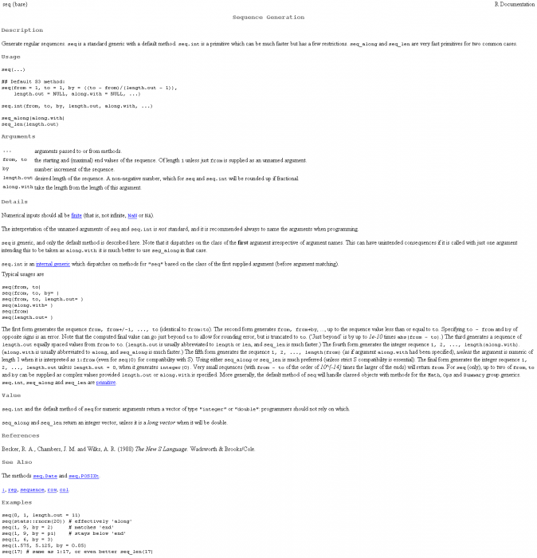

Una página de ayuda generalmente contiene los siguientes elementos y secciones (Nota: a veces, la misma página de ayuda se usa para más de una función):

- En la esquina superior izquierda, el nombre de la función y el paquete al que pertenece en el formato `función {paquete}`
- **Descripción**: una breve descripción de la(s) función(es)
- **Uso**: cómo usar la (s) función (es), especialmente cuál es el nombre y el orden de los argumentos. Si se especifica un valor cerca de un nombre de argumento, significa que se ha definido un valor predeterminado para este argumento, lo que hace que sea opcional especificar otro valor. Si falta el argumento, se utilizará el valor predeterminado. Por ejemplo, si no proporcionamos un argumento `from`, la secuencia comenzará automáticamente desde `1`.
- **Argumentos**: una descripción detallada de todos los argumentos y lo que se espera o requiere para que la función funcione correctamente. **¡Cuidado!** Aquí se enumeran todos los argumentos para todas las funciones descritas en la página de ayuda; no todos los argumentos están disponibles para todas las funciones enumeradas. Por ejemplo, en esta página de ayuda, los argumentos `from` y `to` no están disponibles para la función `seq_along()`.
- **Detalles**: proporcione detalles en profundidad del funcionamiento interno de las funciones. Algunos casos específicos se pueden discutir aquí o se puede proporcionar información adicional.
- **Valor**: explica cuál es el valor de retorno de la función.
- **Referencias**: Fuentes utilizadas como base para la función o lecturas interesantes sobre el tema.
- **Ver también**: Funciones relacionadas que en ocasiones pueden ser de utilidad, especialmente cuando se busca la función correcta para nuestras necesidades.
- **Ejemplos**: algunos ejemplos sobre cómo utilizar las funciones.
- EJERCICIO 12:
1. Crea una secuencia de números pares del 0 al 10 usando la función `seq`
2. - Crea un vector sin clasificar de tus números favoritos.
   - Descubre cómo ordenarlo usando `?sort` (clasificar).
   - Ordena tu vector en orden inverso.

**Solución a)**

```r
seq(from = 0, to = 10, by = 2)
## [1]  0  2  4  6  8 10

# otra forma de escribirlo:
seq(0, 10, 2)
## [1]  0  2  4  6  8 10
```

**Solución b)**

```r
mi_secuencia <- c(2, 4, 22, 6, 26)
sort(mi_secuencia, decreasing = TRUE)
## [1] 26 22  6  4  2
```

### Obteniendo ayuda en la Web

Por lo general, la mejor fuente de información será nuestro motor de búsqueda favorito (Google, Bing, Yahoo, etc.)

Esta es una lista de algunos consejos sobre cómo utilizarlos:

- Busca en inglés
- Utiliza la palabra clave “R” al comienzo de su búsqueda.
- Define con precisión lo que busca
- Aprende a leer foros de discusión. Es probable que otras personas ya hayan tenido el mismo problema y hayan preguntado al respecto. Busca en foros donde a menudo se hacen preguntas sobre R, como [stackexchange](https://stats.stackexchange.com/questions/tagged/r) o [stackoverflow](https://stackoverflow.com/questions/tagged/r). También hay algunas preguntas en español en [stackoverflow en español](https://es.stackoverflow.com/questions/tagged/r)
- ¡No dudes en volver a buscar con diferentes palabras clave!

## Recursos adicionales

### Cheat sheets (hojas de truco)

https://www.rstudio.com/resources/cheatsheets/ Estas hojas de trucos también están disponibles directamente en RStudio y algunas de ellas han sido traducidas al español y otros idiomas!

### Libros

En este enlace puedes encontrar varios libros (gratis!!) que pueden ayudar a aprender mas sobre R: https://cran.r-project.org/other-docs.html#nenglish. Busca en la seccion de español.